# DecisionTree

#### Testing

```r
# True Performance after pruning
pred.ID3_prune.test <- predict(Tree.ID3_prune,
                    newdata=testing,
                    type="class")

perform.ID3_prune.True <- ModelPerformance(pred.ID3_prune.test, testing[,Y_attribute])

## Confusion Matrix
perform.ID3_prune.True$confusion_matrix
```

```
##                  true_condition
## predict_condition  No Yes
##               No  155  47
##               Yes   1  18
```

```r
## Accuracy
perform.ID3_prune.True$ACC
```

```
## [1] 0.7828054
```

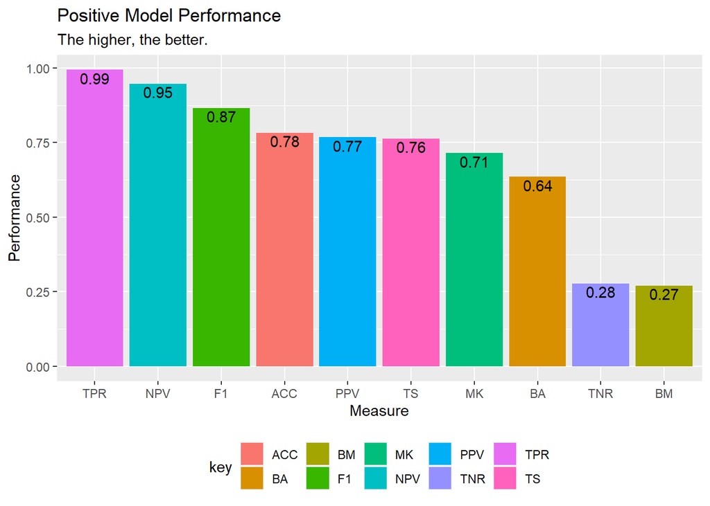

```r
perform.ID3_prune.True$plot_positive
```

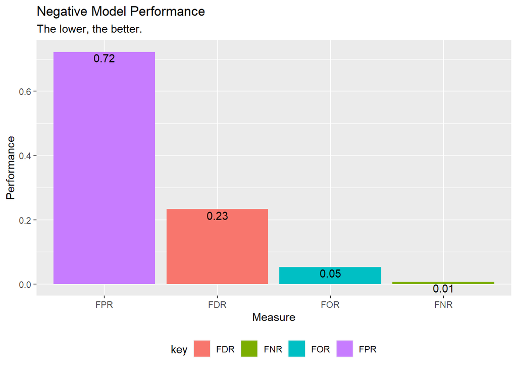

```r
perform.ID3_prune.True$plot_negative
```

### 6. Conclusion

[output not shown]

## C4_5

### Install RWeka

1. If Java hasn’t been installed : https://www.java.com/zh_TW/download/win10.jsp
2. Sys.setenv(JAVA_HOME=‘C:\Program Files\Java\jdk1.8.0_191\jre’)
3. install.packages(“RWeka”)

### 0. Setting

[Weka_control parameters](https://rdrr.io/cran/RWeka/man/Weka_control.html)

```r
data = BreastCancer
train_proportion = 0.9
set.seed(20200418)
formula = formula(irradiate ~ .)
Y_attribute = 'irradiate'

Control.C45.Unprune = RWeka::Weka_control(
                       U = TRUE,  # Use unpruned tree
                       R= FALSE, # Use reduced error pruning (REP)
                       M=2, # Minimum number of instances per leaf
                       B=FALSE # Use binary splits only
                       )

Control.C45.Prune = RWeka::Weka_control(
                       U = FALSE,
                       R= TRUE,
                       M=2,
                       B=FALSE
                       )
```

### 1. Model

```r
library(RWeka)
library(pROC)

dataPartition = Partition(data, train_proportion)

training = dataPartition$training
testing = dataPartition$testing


Tree.C45 <- J48(formula = formula,
                data = training,
                control = Control.C45.Prune)
```

### 2. Plot

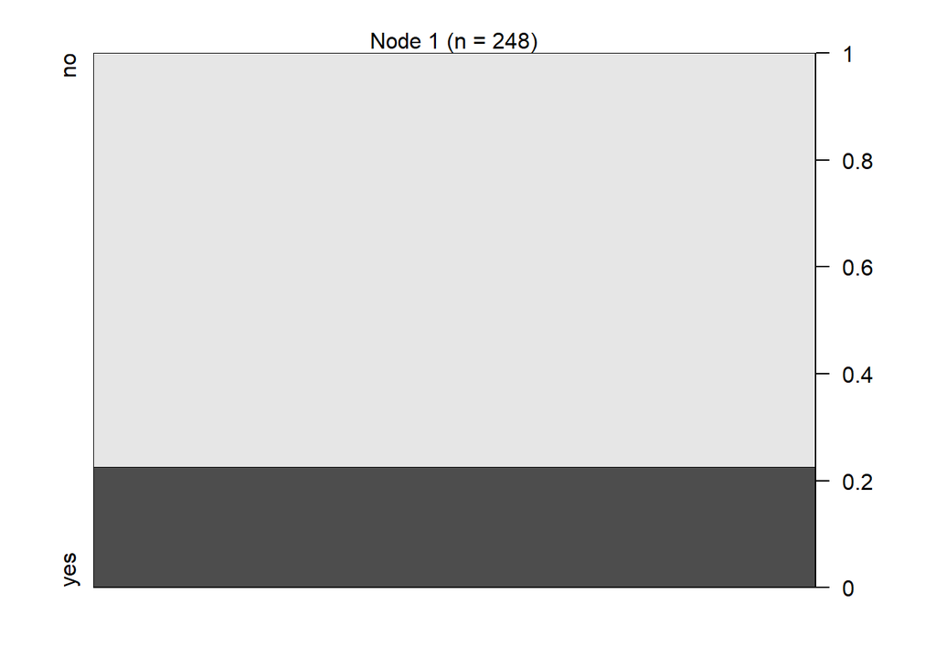

```r
require(partykit)
plot(Tree.C45)
```

### 3. Predict

#### Training

```r
pred.C45.train = predict(Tree.C45,
                         newdata=training,
                         type = "class")

perform.C45.Apparent <- ModelPerformance(pred.C45.train, training[,Y_attribute])
perform.C45.Apparent$confusion_matrix
```

```
##                  true_condition
## predict_condition  no yes
##               no  195  62
##               yes   0   0
```

```r
perform.C45.Apparent$ACC
```

```
## [1] 0.7587549
```

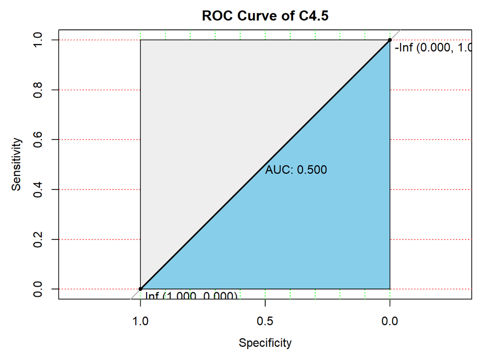

```r
library(pROC)

pred.C45.train.prob = predict(Tree.C45,
                         newdata=training,
                         type = "prob")


roc.C45.train <- roc(response = training[,Y_attribute],
               predictor = pred.C45.train.prob[,2],
               plot = T,
               print.auc=TRUE,
               auc.polygon=TRUE,
               grid=c(0.1, 0.2),
               grid.col=c("green", "red"),
               max.auc.polygon=TRUE,
               auc.polygon.col="skyblue",
               print.thres=TRUE,
               main='ROC Curve of C4.5')
```

```r
roc.C45.train
```

```
##
## Call:
## roc.default(response = training[, Y_attribute], predictor = pred.C45.train.prob[,     2], plot = T, print.auc = TRUE, auc.polygon = TRUE, grid = c(0.1,     0.2), grid.col = c("green", "red"), max.auc.polygon = TRUE,     auc.polygon.col = "skyblue", print.thres = TRUE, main = "ROC Curve of C4.5")
##
## Data: pred.C45.train.prob[, 2] in 195 controls (training[, Y_attribute] no) < 62 cases (training[, Y_attribute] yes).
## Area under the curve: 0.5
```

#### Testing

```r
# True Performance
pred.C45.test <- predict(Tree.C45,
                    newdata=testing,
                    type="class")

perform.C45.True <- ModelPerformance(pred.C45.test, testing[,Y_attribute])
perform.C45.True$confusion_matrix
```

```
##                  true_condition
## predict_condition no yes
##               no  23   6
##               yes  0   0
```

```r
perform.C45.True$ACC
```

```
## [1] 0.7931034
```

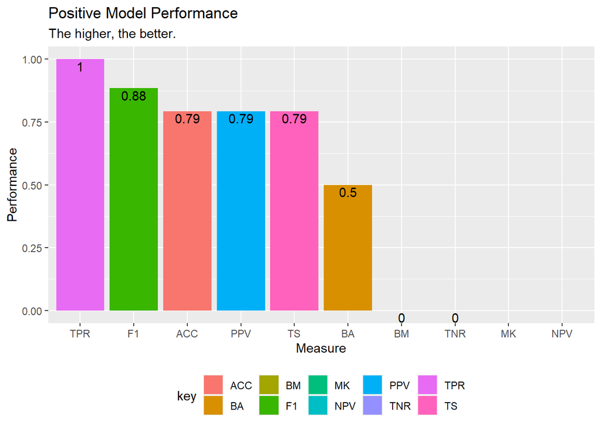

```r
perform.C45.True$plot_positive
```

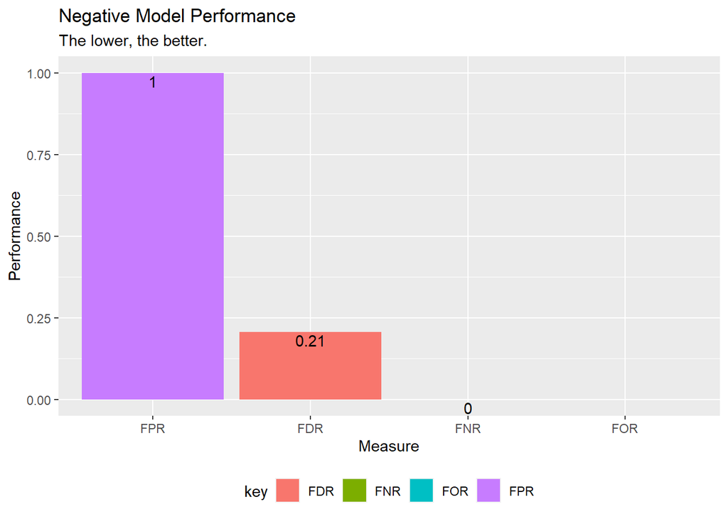

```r
perform.C45.True$plot_negative
```

## CART

### 0. Setting

```r
set.seed(20200418)
data = iris
train_proportion = 0.9
formula = formula(Species  ~ .)
Y_attribute = 'Species'

Control.CART = rpart::rpart.control(
                      minsplit = 8, # min obs. in node --- too small cause over-fitting
                      minbucket = 1, # min obs. in leaf--- too small cause over-fitting
                      cp = 0, # complex parameter --- too small cause over-fitting
                      xval = 10, # cross validation
                      maxdepth = 30, # The root node counted as depth 0
                      maxcompete = 4,
                      maxsurrogate = 5,
                      usesurrogate = 2,
                      surrogatestyle = 0)
```

### 1. Model

```r
library(rpart)

dataPartition = Partition(data, train_proportion)

training = dataPartition$training
testing = dataPartition$testing



Tree.CART <- rpart(formula = formula,
                  data = training,
                  method="class",
                  na.action = na.rpart,
                  parms=list(split="gini"),
                  control = Control.CART
                  )
Tree.CART
```

```
## n= 135
##
## node), split, n, loss, yval, (yprob)
##       * denotes terminal node
##
##  1) root 135 86 virginica (0.31851852 0.31851852 0.36296296)
##    2) Petal.Length< 2.45 43  0 setosa (1.00000000 0.00000000 0.00000000) *
##    3) Petal.Length>=2.45 92 43 virginica (0.00000000 0.46739130 0.53260870)
##      6) Petal.Width< 1.75 48  5 versicolor (0.00000000 0.89583333 0.10416667)
##       12) Petal.Length< 4.95 42  1 versicolor (0.00000000 0.97619048 0.02380952)
##         24) Sepal.Length>=4.95 41  0 versicolor (0.00000000 1.00000000 0.00000000) *
##         25) Sepal.Length< 4.95 1  0 virginica (0.00000000 0.00000000 1.00000000) *
##       13) Petal.Length>=4.95 6  2 virginica (0.00000000 0.33333333 0.66666667) *
##      7) Petal.Width>=1.75 44  0 virginica (0.00000000 0.00000000 1.00000000) *
```

### 2. Plot

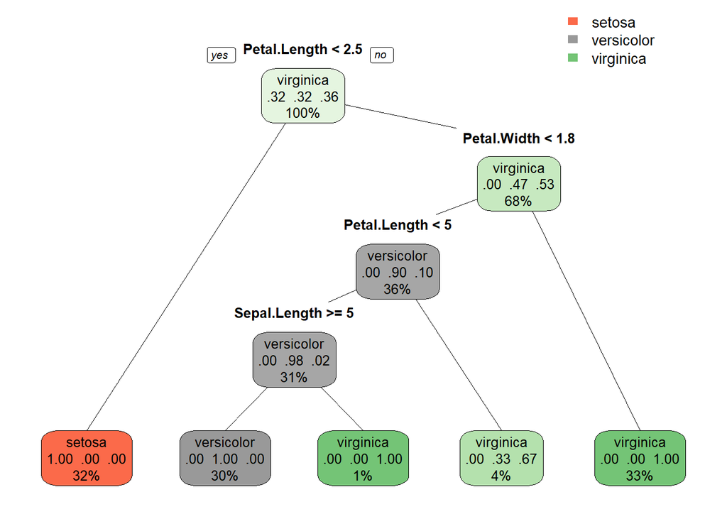

```r
library(rpart.plot)
rpart.plot(Tree.CART,
           branch=0, # tree shape
           type = 1, # node shape
           cex=0.8, # sign size
           fallen.leaves=T)
```

### 3. Predict

#### Training

```r
# Apparent Performance
pred.CART.train <- predict(Tree.CART,
                    newdata=training,
                    type="class")

perform.CART.Apparent <- ModelPerformance(pred.CART.train, training[,Y_attribute])

## Confusion Matrix
perform.CART.Apparent$confusion_matrix
```

```
##                  true_condition
## predict_condition setosa versicolor virginica
##        setosa         43          0         0
##        versicolor      0         41         0
##        virginica       0          2        49
```

```r
## Accuracy
perform.CART.Apparent$ACC
```

```
## [1] 0.9851852
```

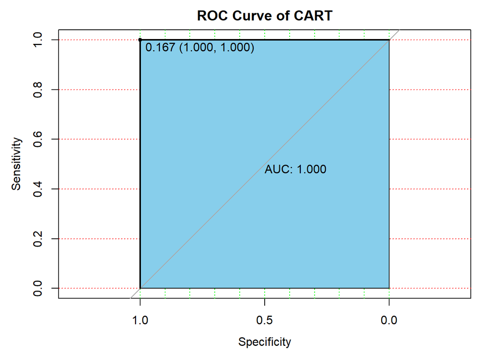

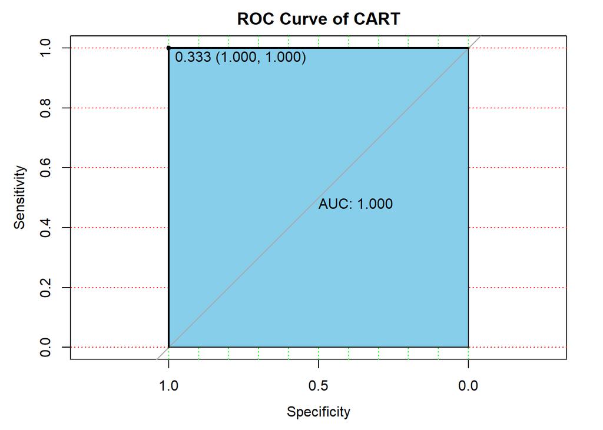

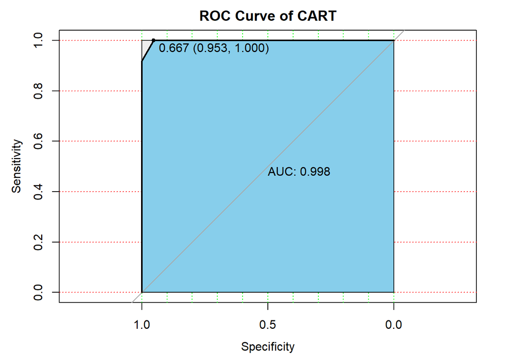

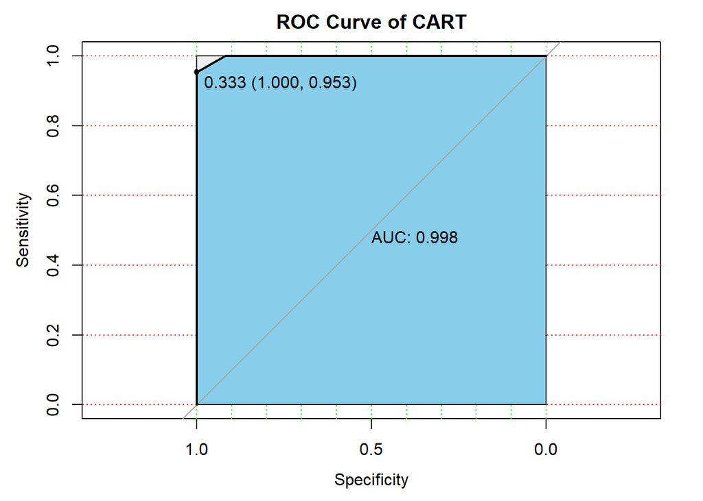

```r
library(pROC)

pred.CART.train.prob = predict(Tree.CART,
                         newdata=training,
                         type = "prob")


roc.CART.train <- multiclass.roc(response = training[,Y_attribute],
               predictor = pred.CART.train.prob,
               plot = T,
               print.auc=TRUE,
               auc.polygon=TRUE,
               grid=c(0.1, 0.2),
               grid.col=c("green", "red"),
               max.auc.polygon=TRUE,
               auc.polygon.col="skyblue",
               print.thres=TRUE,
               main='ROC Curve of CART')
```

```r
roc.CART.train$rocs
```

```
## $`setosa/versicolor`
## $`setosa/versicolor`[[1]]
##
## Call:
## roc.default(response = classes, predictor = predictor, levels = levels,     percent = percent, direction = direction, auc = FALSE, ci = FALSE,     plot = ..1, print.auc = TRUE, auc.polygon = TRUE, grid = ..4,     grid.col = ..5, max.auc.polygon = TRUE, auc.polygon.col = "skyblue",     print.thres…
##
## Data: predictor in 43 controls (classes 1) > 43 cases (classes 2).
## Area under the curve not computed.
##
## $`setosa/versicolor`[[2]]
##
## Call:
## roc.default(response = classes, predictor = predictor, levels = levels,     percent = percent, direction = direction, auc = FALSE, ci = FALSE,     plot = ..1, print.auc = TRUE, auc.polygon = TRUE, grid = ..4,     grid.col = ..5, max.auc.polygon = TRUE, auc.polygon.col = "skyblue",     print.thres…
##
## Data: predictor in 43 controls (classes 2) > 43 cases (classes 1).
## Area under the curve not computed.
##
##
## $`setosa/virginica`
## $`setosa/virginica`[[1]]
##
## Call:
## roc.default(response = classes, predictor = predictor, levels = levels,     percent = percent, direction = direction, auc = FALSE, ci = FALSE,     plot = ..1, print.auc = TRUE, auc.polygon = TRUE, grid = ..4,     grid.col = ..5, max.auc.polygon = TRUE, auc.polygon.col = "skyblue",     print.thres…
##
## Data: predictor in 43 controls (classes 1) > 49 cases (classes 2).
## Area under the curve not computed.
##
## $`setosa/virginica`[[2]]
##
## Call:
## roc.default(response = classes, predictor = predictor, levels = levels,     percent = percent, direction = direction, auc = FALSE, ci = FALSE,     plot = ..1, print.auc = TRUE, auc.polygon = TRUE, grid = ..4,     grid.col = ..5, max.auc.polygon = TRUE, auc.polygon.col = "skyblue",     print.thres…
##
## Data: predictor in 49 controls (classes 2) > 43 cases (classes 1).
## Area under the curve not computed.
##
##
## $`versicolor/virginica`
## $`versicolor/virginica`[[1]]
##
## Call:
## roc.default(response = classes, predictor = predictor, levels = levels,     percent = percent, direction = direction, auc = FALSE, ci = FALSE,     plot = ..1, print.auc = TRUE, auc.polygon = TRUE, grid = ..4,     grid.col = ..5, max.auc.polygon = TRUE, auc.polygon.col = "skyblue",     print.thres…
##
## Data: predictor in 43 controls (classes 1) > 49 cases (classes 2).
## Area under the curve not computed.
##
## $`versicolor/virginica`[[2]]
##
## Call:
## roc.default(response = classes, predictor = predictor, levels = levels,     percent = percent, direction = direction, auc = FALSE, ci = FALSE,     plot = ..1, print.auc = TRUE, auc.polygon = TRUE, grid = ..4,     grid.col = ..5, max.auc.polygon = TRUE, auc.polygon.col = "skyblue",     print.thres…
##
## Data: predictor in 49 controls (classes 2) > 43 cases (classes 1).
## Area under the curve not computed.
```

#### Testing

```r
# True Performance
pred.CART.test <- predict(Tree.CART,
                    newdata=testing,
                    type="class")

perform.CART.True <- ModelPerformance(pred.CART.test, testing[,Y_attribute])

## Confusion Matrix
perform.CART.True$confusion_matrix
```

```
##                  true_condition
## predict_condition setosa versicolor virginica
##        setosa          7          0         0
##        versicolor      0          5         0
##        virginica       0          2         1
```

```r
## Accuracy
perform.CART.True$ACC
```

```
## [1] 0.8666667
```

### 4. Prune

- To look up a proper cp, look up **lower** cross-validation error(**xerror**).
- Don’t always choose the lowest xerror,**more simplified tree** should also be considered.
- After over-fitting,try pruning the tree by **larger** cp.

```r
printcp(Tree.CART)
```

```
##
## Classification tree:
## rpart(formula = formula, data = training, na.action = na.rpart,
##     method = "class", parms = list(split = "gini"), control = Control.CART)
##
## Variables actually used in tree construction:
## [1] Petal.Length Petal.Width  Sepal.Length
##
## Root node error: 86/135 = 0.63704
##
## n= 135
##
##         CP nsplit rel error   xerror     xstd
## 1 0.500000      0  1.000000 1.000000 0.064965
## 2 0.441860      1  0.500000 0.500000 0.062945
## 3 0.023256      2  0.058140 0.093023 0.031899
## 4 0.011628      3  0.034884 0.093023 0.031899
## 5 0.000000      4  0.023256 0.069767 0.027842
```

```r
Tree.CART_prune <- prune(Tree.CART,cp= 0.02)
Tree.CART_prune
```

```
## n= 135
##
## node), split, n, loss, yval, (yprob)
##       * denotes terminal node
##
##  1) root 135 86 virginica (0.31851852 0.31851852 0.36296296)
##    2) Petal.Length< 2.45 43  0 setosa (1.00000000 0.00000000 0.00000000) *
##    3) Petal.Length>=2.45 92 43 virginica (0.00000000 0.46739130 0.53260870)
##      6) Petal.Width< 1.75 48  5 versicolor (0.00000000 0.89583333 0.10416667)
##       12) Petal.Length< 4.95 42  1 versicolor (0.00000000 0.97619048 0.02380952) *
##       13) Petal.Length>=4.95 6  2 virginica (0.00000000 0.33333333 0.66666667) *
##      7) Petal.Width>=1.75 44  0 virginica (0.00000000 0.00000000 1.00000000) *
```

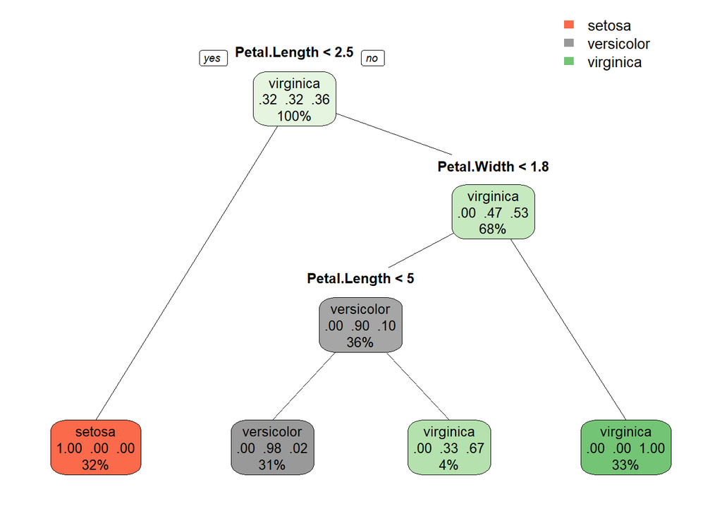

```r
rpart.plot(Tree.CART_prune,
           branch=0, # tree shape
           type = 1, # node shape
           cex=0.8, # sign size
           fallen.leaves=T)
```

### 5. Predict (pruned)

#### Training

```r
# Apparent Performance after pruning
pred.CART_prune.train <- predict(Tree.CART_prune,
                    newdata=training,
                    type="class")

perform.CART_prune.Apparent <- ModelPerformance(pred.CART_prune.train, training[,Y_attribute])
## Confusion Matrix
perform.CART_prune.Apparent$confusion_matrix
```

```
##                  true_condition
## predict_condition setosa versicolor virginica
##        setosa         43          0         0
##        versicolor      0         41         1
##        virginica       0          2        48
```

```r
## Accuracy
perform.CART_prune.Apparent$ACC
```

```
## [1] 0.9777778
```

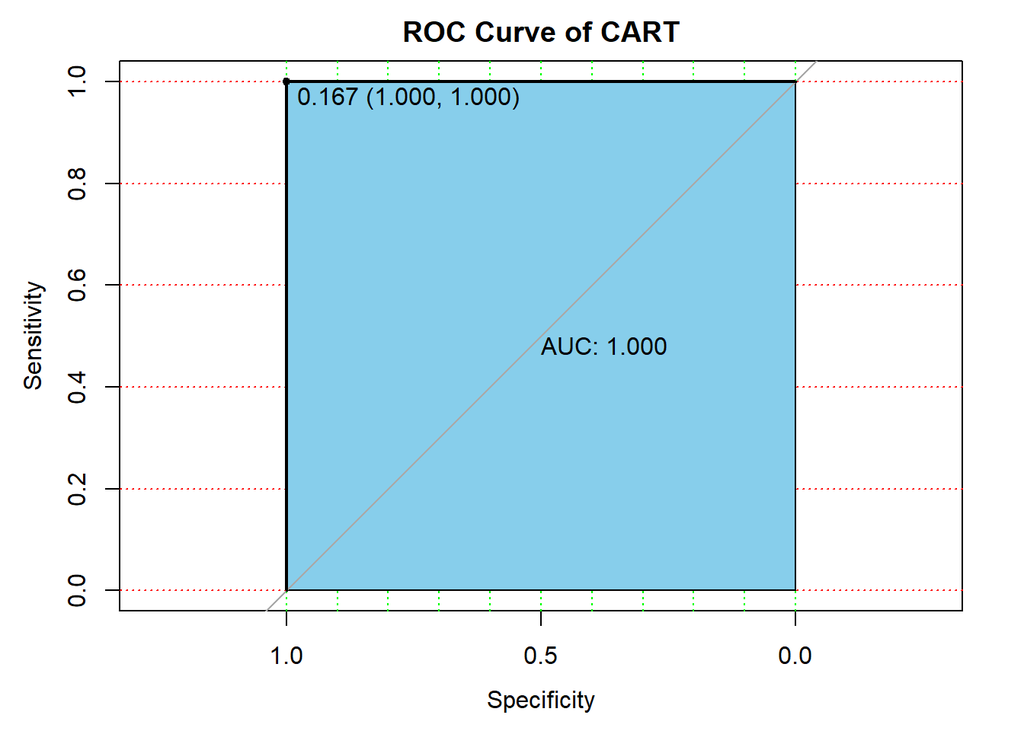

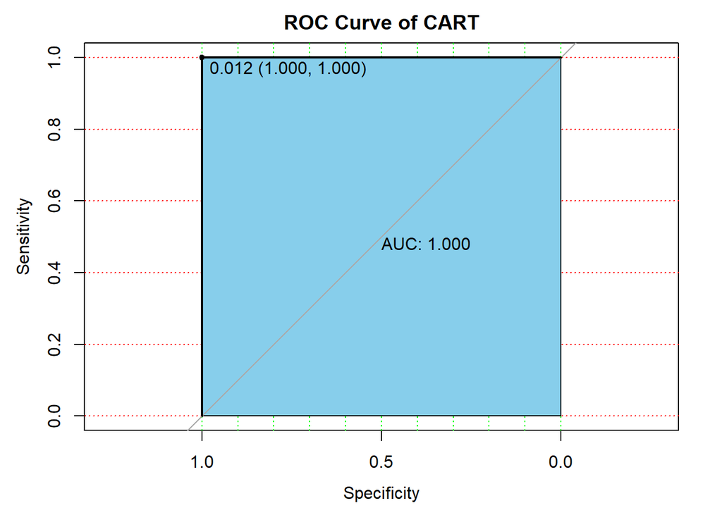

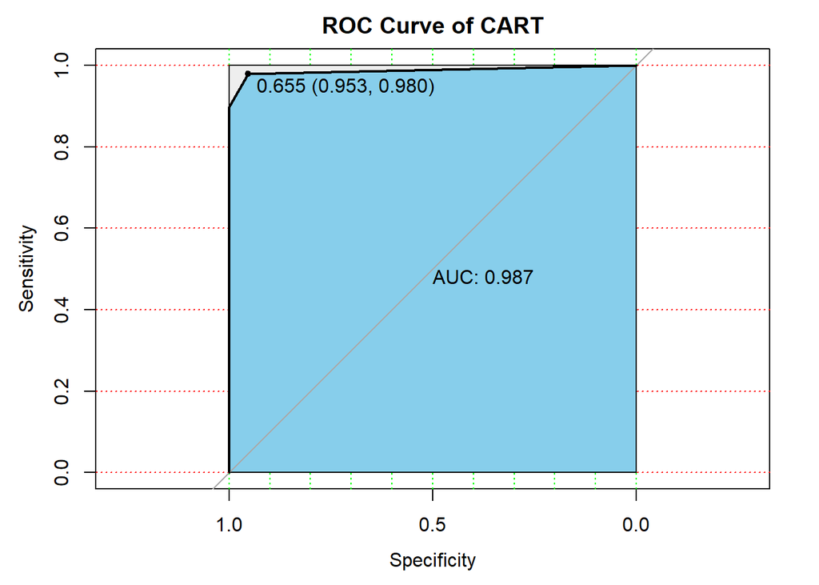

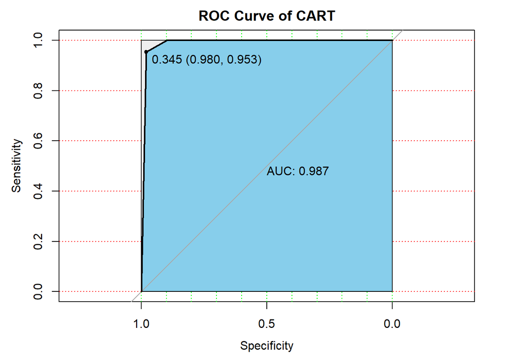

```r
library(pROC)

pred.CART_prune.train.prob = predict(Tree.CART_prune,
                         newdata=training,
                         type = "prob")

## There are 3 classes in Species of iris.
roc.CART_prune.train <- multiclass.roc(response = training[,Y_attribute],
               predictor = pred.CART_prune.train.prob,
               plot = T,
               print.auc=TRUE,
               auc.polygon=TRUE,
               grid=c(0.1, 0.2),
               grid.col=c("green", "red"),
               max.auc.polygon=TRUE,
               auc.polygon.col="skyblue",
               print.thres=TRUE,
               main='ROC Curve of CART')
```

```r
roc.CART_prune.train$rocs
```

```
## $`setosa/versicolor`
## $`setosa/versicolor`[[1]]
##
## Call:
## roc.default(response = classes, predictor = predictor, levels = levels,     percent = percent, direction = direction, auc = FALSE, ci = FALSE,     plot = ..1, print.auc = TRUE, auc.polygon = TRUE, grid = ..4,     grid.col = ..5, max.auc.polygon = TRUE, auc.polygon.col = "skyblue",     print.thres…
##
## Data: predictor in 43 controls (classes 1) > 43 cases (classes 2).
## Area under the curve not computed.
##
## $`setosa/versicolor`[[2]]
##
## Call:
## roc.default(response = classes, predictor = predictor, levels = levels,     percent = percent, direction = direction, auc = FALSE, ci = FALSE,     plot = ..1, print.auc = TRUE, auc.polygon = TRUE, grid = ..4,     grid.col = ..5, max.auc.polygon = TRUE, auc.polygon.col = "skyblue",     print.thres…
##
## Data: predictor in 43 controls (classes 2) > 43 cases (classes 1).
## Area under the curve not computed.
##
##
## $`setosa/virginica`
## $`setosa/virginica`[[1]]
##
## Call:
## roc.default(response = classes, predictor = predictor, levels = levels,     percent = percent, direction = direction, auc = FALSE, ci = FALSE,     plot = ..1, print.auc = TRUE, auc.polygon = TRUE, grid = ..4,     grid.col = ..5, max.auc.polygon = TRUE, auc.polygon.col = "skyblue",     print.thres…
##
## Data: predictor in 43 controls (classes 1) > 49 cases (classes 2).
## Area under the curve not computed.
##
## $`setosa/virginica`[[2]]
##
## Call:
## roc.default(response = classes, predictor = predictor, levels = levels,     percent = percent, direction = direction, auc = FALSE, ci = FALSE,     plot = ..1, print.auc = TRUE, auc.polygon = TRUE, grid = ..4,     grid.col = ..5, max.auc.polygon = TRUE, auc.polygon.col = "skyblue",     print.thres…
##
## Data: predictor in 49 controls (classes 2) > 43 cases (classes 1).
## Area under the curve not computed.
##
##
## $`versicolor/virginica`
## $`versicolor/virginica`[[1]]
##
## Call:
## roc.default(response = classes, predictor = predictor, levels = levels,     percent = percent, direction = direction, auc = FALSE, ci = FALSE,     plot = ..1, print.auc = TRUE, auc.polygon = TRUE, grid = ..4,     grid.col = ..5, max.auc.polygon = TRUE, auc.polygon.col = "skyblue",     print.thres…
##
## Data: predictor in 43 controls (classes 1) > 49 cases (classes 2).
## Area under the curve not computed.
##
## $`versicolor/virginica`[[2]]
##
## Call:
## roc.default(response = classes, predictor = predictor, levels = levels,     percent = percent, direction = direction, auc = FALSE, ci = FALSE,     plot = ..1, print.auc = TRUE, auc.polygon = TRUE, grid = ..4,     grid.col = ..5, max.auc.polygon = TRUE, auc.polygon.col = "skyblue",     print.thres…
##
## Data: predictor in 49 controls (classes 2) > 43 cases (classes 1).
## Area under the curve not computed.
```

#### Testing

```r
# True Performance after pruning
pred.CART_prune.test <- predict(Tree.CART_prune,
                    newdata=testing,
                    type="class")

perform.CART_prune.True <- ModelPerformance(pred.CART_prune.test, testing[,Y_attribute])

## Confusion Matrix
perform.CART_prune.True$confusion_matrix
```

```
##                  true_condition
## predict_condition setosa versicolor virginica
##        setosa          7          0         0
##        versicolor      0          6         0
##        virginica       0          1         1
```

```r
## Accuracy
perform.CART_prune.True$ACC
```

```
## [1] 0.9333333
```

### 6. Conclusion

| CP Threshold | 0 (unpruned) | 0.02 (pruned) | Trend |
| --- | --- | --- | --- |
| Training | 98.52% | 97.77% | ↓ (-0.75%) |
| Testing | 86.67% | 93.33% | ↑ (+6.66%) |

## C5_0

C5.0Control Parameters:https://cran.r-project.org/web/packages/C50/C50.pdf

### 0. Setting

```r
data = BreastCancer
train_proportion = 0.9
set.seed(20200418)
formula = formula(irradiate  ~ .)
Y_attribute = 'irradiate'


Control.C50 =C50::C5.0Control(
                 subset = FALSE,
                 bands = 0, # when betewwn 2 and 1000, rules = TRUE
                 winnow = FALSE,
                 noGlobalPruning = TRUE, # The final global pruning step
                 CF = 0.25,
                 minCases = 2,
                 fuzzyThreshold = FALSE,
                 sample = 0,
                 seed = sample.int(4096, size = 1) -1L,
                 earlyStopping = TRUE
                 )
```

### 1. Model

```r
library(C50)
dataPartition = Partition(data, train_proportion)

training = dataPartition$training
testing = dataPartition$testing


Tree.C50 <- C5.0(x = dplyr::select(training, -Y_attribute),
                 y = training[,Y_attribute],
                 control =Control.C50,
                 trials = 10, # boosting iteration
                 rules = FALSE
                 )
```

```
## Note: Using an external vector in selections is ambiguous.
## i Use `all_of(Y_attribute)` instead of `Y_attribute` to silence this message.
## i See <https://tidyselect.r-lib.org/reference/faq-external-vector.html>.
```

```r
summary(Tree.C50)
```

```
##
## Call:
## C5.0.default(x = dplyr::select(training, -Y_attribute), y =
##  training[, Y_attribute], trials = 10, rules = FALSE, control = Control.C50)
##
##
## C5.0 [Release 2.07 GPL Edition]      Thu Apr 16 19:58:03 2020
## -------------------------------
##
## Class specified by attribute `outcome'
##
## Read 257 cases (10 attributes) from undefined.data
##
## -----  Trial 0:  -----
##
## Decision tree:
##
## inv-nodes in {0-2,15-17}: no (200/28)
## inv-nodes in {12-14,24-26,9-11}: yes (12/3)
## inv-nodes = 6-8:
## :...tumor-size in {0-4,5-9,50-54}: yes (0)
## :   tumor-size in {10-14,15-19,20-24,25-29,40-44}: yes (8)
## :   tumor-size in {30-34,35-39,45-49}: no (8/1)
## inv-nodes = 3-5:
## :...age in {20-29,70-79}: no (0)
##     age = 50-59: no (9/2)
##     age = 30-39:
##     :...deg-malig = 1: yes (0)
##     :   deg-malig = 2: no (3/1)
##     :   deg-malig = 3: yes (2)
##     age = 40-49:
##     :...tumor-size in {0-4,10-14,15-19,25-29,35-39,45-49,5-9,
##     :   :              50-54}: no (0)
##     :   tumor-size in {20-24,40-44}: yes (5/1)
##     :   tumor-size = 30-34: no (3)
##     age = 60-69:
##     :...Class = no-recurrence-events: yes (3)
##         Class = recurrence-events:
##         :...breast = left: yes (2)
##             breast = right: no (2)
```

[output cut: 146 more lines]

```
##
##  Attribute usage:
##
##  100.00% age
##  100.00% inv-nodes
##   97.28% node-caps
##   86.77% menopause
##   84.82% tumor-size
##   60.31% Class
##   54.47% deg-malig
##   46.69% breast-quad
##   34.63% breast
##
##
## Time: 0.0 secs
```

### 2. Plot

[figure not shown]

```r
plot(Tree.C50)
```

### 3. Predict

#### Training

```r
# Apparent Performance
pred.C50.train <- predict(Tree.C50,
                    newdata=training,
                    type="class")

perform.C50.Apparent <- ModelPerformance(pred.C50.train, training[,Y_attribute])

## Confusion Matrix
perform.C50.Apparent$confusion_matrix
```

```
##                  true_condition
## predict_condition  no yes
##               no  192  31
##               yes   5  29
```

```r
## Accuracy
perform.C50.Apparent$ACC
```

```
## [1] 0.8599222
```

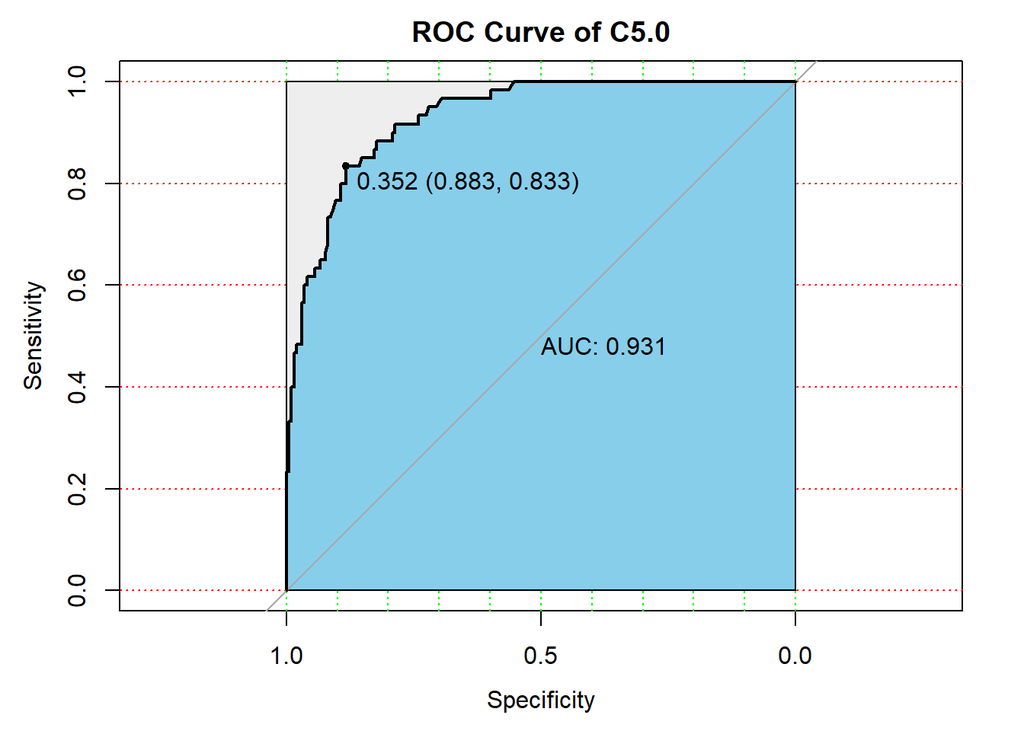

```r
library(pROC)

pred.C50.train.prob = predict(Tree.C50,
                         newdata=training,
                         type = "prob")


roc.C50.train <- roc(response = training[,Y_attribute],
               predictor = pred.C50.train.prob[,2],
               plot = T,
               print.auc=TRUE,
               auc.polygon=TRUE,
               grid=c(0.1, 0.2),
               grid.col=c("green", "red"),
               max.auc.polygon=TRUE,
               auc.polygon.col="skyblue",
               print.thres=TRUE,
               main='ROC Curve of C5.0')
```

```r
roc.C50.train
```

```
##
## Call:
## roc.default(response = training[, Y_attribute], predictor = pred.C50.train.prob[,     2], plot = T, print.auc = TRUE, auc.polygon = TRUE, grid = c(0.1,     0.2), grid.col = c("green", "red"), max.auc.polygon = TRUE,     auc.polygon.col = "skyblue", print.thres = TRUE, main = "ROC Curve of C5.0")
##
## Data: pred.C50.train.prob[, 2] in 197 controls (training[, Y_attribute] no) < 60 cases (training[, Y_attribute] yes).
## Area under the curve: 0.9307
```

#### Testing

```r
# True Performance
pred.C50.test <- predict(Tree.C50,
                    newdata=testing,
                    type="class")

perform.C50.True <- ModelPerformance(pred.C50.test, testing[,Y_attribute])

## Confusion Matrix
perform.C50.True$confusion_matrix
```

```
##                  true_condition
## predict_condition no yes
##               no  18   4
##               yes  3   4
```

```r
## Accuracy
perform.C50.True$ACC
```

```
## [1] 0.7586207
```

[figure not shown]

```r
perform.C45.True$plot_positive
```

[figure not shown]

```r
perform.C45.True$plot_negative
```

### 4. Conclusion

## CHAID

How to install CHAID package: + Check CHAID version: http://download.r-forge.r-project.org/src/contrib/ + install.packages(“http://download.r-forge.r-project.org/src/contrib/CHAID_0.1-2.tar.gz”, repos = NULL)

### 0. Setting

```r
data = BreastCancer
train_proportion = 0.9
set.seed(20200418)
formula = formula(irradiate  ~ .)
Y_attribute = 'irradiate'


Control.CHAID = CHAID::chaid_control(
                      alpha2 = 0.05, # for merging
                      alpha3 = 0.01,  # for spliting
                      alpha4 = 0.05, # for feature selection
                      minsplit = 10,
                      minbucket = 3,
                      maxheight = 30,
                      minprob = 0.01,  # min proportion in leaf node (to total sample)
                      stump = FALSE # only split root node
                     )
```

### 1. Model

```r
library(CHAID)

dataPartition = Partition(data, train_proportion)

training = dataPartition$training
testing = dataPartition$testing

Tree.CHAID <- chaid(formula = formula,
                    data = training,
                    control = Control.CHAID)

Tree.CHAID
```

```
##
## Model formula:
## irradiate ~ Class + age + menopause + `tumor-size` + `inv-nodes` +
##     `node-caps` + `deg-malig` + breast + `breast-quad`
##
## Fitted party:
## [1] root
## |   [2] node-caps in no
## |   |   [3] inv-nodes in 12-14, 15-17, 24-26, 6-8, 9-11: yes (n = 4, err = 25.0%)
## |   |   [4] inv-nodes in 0-2
## |   |   |   [5] Class in no-recurrence-events: no (n = 149, err = 9.4%)
## |   |   |   [6] Class in recurrence-events: no (n = 35, err = 22.9%)
## |   |   [7] inv-nodes in 3-5: no (n = 12, err = 41.7%)
## |   [8] node-caps in yes: yes (n = 48, err = 45.8%)
##
## Number of inner nodes:    3
## Number of terminal nodes: 5
```

### 2. Plot

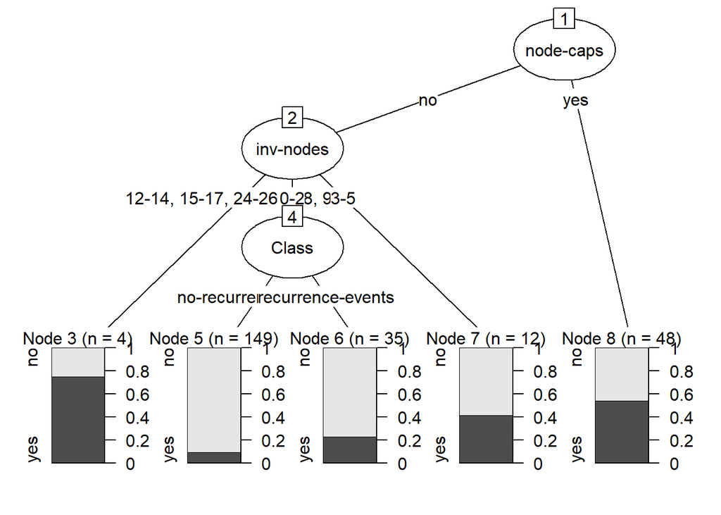

```r
plot(Tree.CHAID)
```

### 3. Predict

#### Training

```r
# Apparent Performance
pred.CHAID.train <- predict(Tree.CHAID,
                    newdata=training,
                    type="response")

perform.CHAID.Apparent <- ModelPerformance(pred.CHAID.train, training[,Y_attribute])

## Confusion Matrix
perform.CHAID.Apparent$confusion_matrix
```

```
##                  true_condition
## predict_condition  no yes
##               no  172  28
##               yes  23  34
```

```r
## Accuracy
perform.CHAID.Apparent$ACC
```

```
## [1] 0.8015564
```

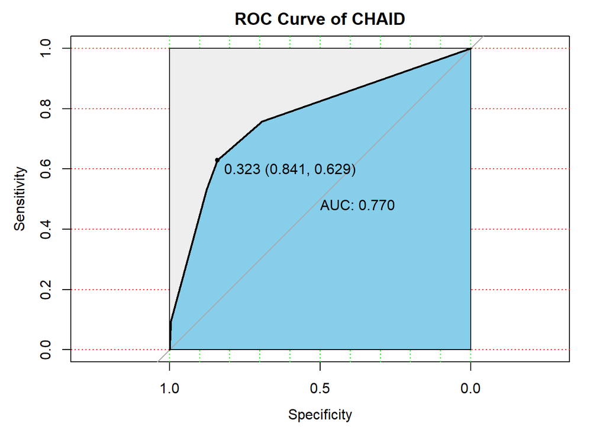

```r
library(pROC)

pred.CHAID.train.prob = predict(Tree.CHAID,
                         newdata=training,
                         type = "prob")


roc.CHAID.train <- roc(response = training[,Y_attribute],
               predictor = pred.CHAID.train.prob[,2],
               plot = T,
               print.auc=TRUE,
               auc.polygon=TRUE,
               grid=c(0.1, 0.2),
               grid.col=c("green", "red"),
               max.auc.polygon=TRUE,
               auc.polygon.col="skyblue",
               print.thres=TRUE,
               main='ROC Curve of CHAID')
```

```r
roc.CHAID.train
```

```
##
## Call:
## roc.default(response = training[, Y_attribute], predictor = pred.CHAID.train.prob[,     2], plot = T, print.auc = TRUE, auc.polygon = TRUE, grid = c(0.1,     0.2), grid.col = c("green", "red"), max.auc.polygon = TRUE,     auc.polygon.col = "skyblue", print.thres = TRUE, main = "ROC Curve of CHAID…
##
## Data: pred.CHAID.train.prob[, 2] in 195 controls (training[, Y_attribute] no) < 62 cases (training[, Y_attribute] yes).
## Area under the curve: 0.7699
```

#### Testing

```r
# True Performance
pred.CHAID.test <- predict(Tree.CHAID,
                    newdata=testing,
                    type="response")

perform.CHAID.True <- ModelPerformance(pred.CHAID.test, testing[,Y_attribute])

## Confusion Matrix
perform.CHAID.True$confusion_matrix
```

```
##                  true_condition
## predict_condition no yes
##               no  16   3
##               yes  7   3
```

```r
## Accuracy
perform.CART.True$ACC
```

[output not shown]

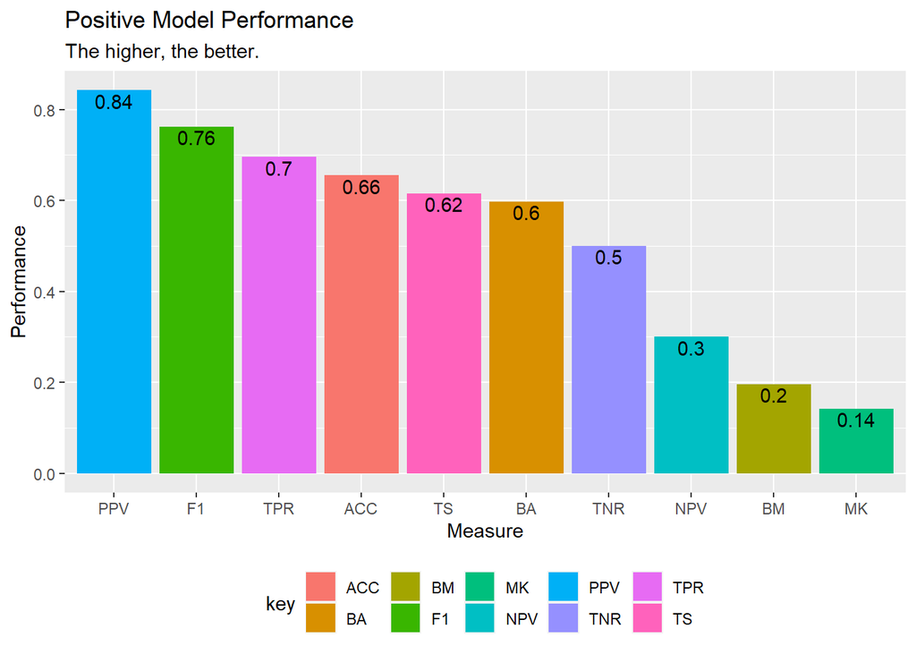

```r
perform.CHAID.True$plot_positive
```

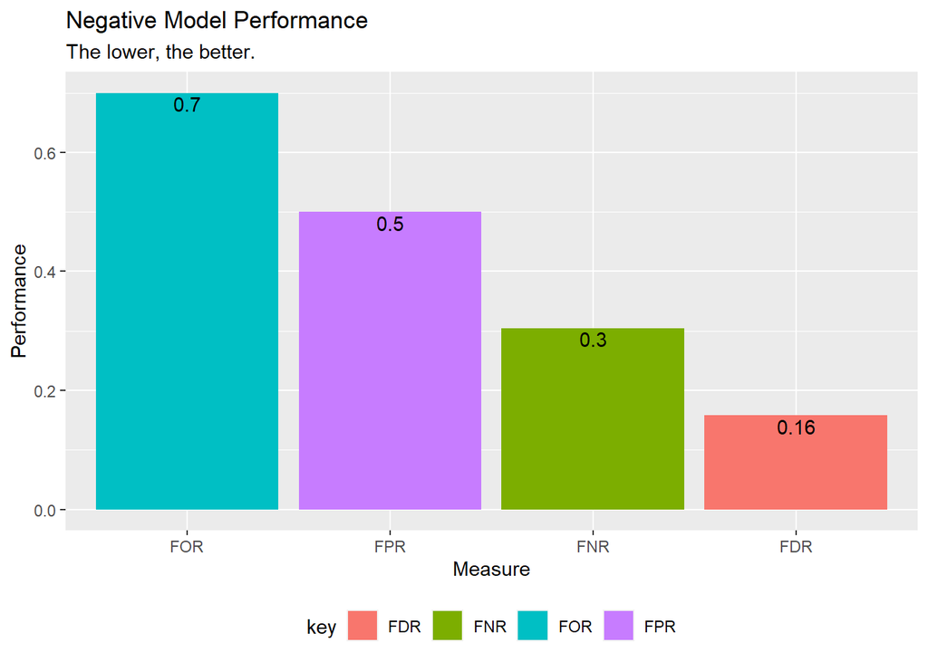

```r
perform.CHAID.True$plot_negative
```

### 0. Setting

### 1. Model

### 2. Plot

### 3. Predict

### 4. Prune

### 5. Predict (prune)

### 6. Conclusion